# UP431 Lab2: Exploring NHTS Data (2)

# Using NHTS Data (2)

We will continue to use the Chicago metropolitan area data. You should get started by importing the data you have saved last week.Reading the RDS file back in is as simple as assigning the output of read_rds(“filename”) to a new object. Since read_rds function is coming from the tidyverse package, you should import the package before you start.

```r
library(tidyverse)
```

```r
chi_trips <- read_rds("C:/Lab0/2021_UP431/Lab1/Output/chi_trips.rds")
```

If the data import was successful, you will see chi_trips on the Environment tab (typically on the right side of the source tab).

```r
names(chi_trips)
```

```
##   [1] "HOUSEID"            "PERSONID"           "TDTRPNUM"
##   [4] "STRTTIME"           "ENDTIME"            "TRVLCMIN"
##   [7] "TRPMILES"           "TRPTRANS"           "TRPACCMP"
##  [10] "TRPHHACC"           "VEHID"              "TRWAITTM"
##  [13] "NUMTRANS"           "TRACCTM"            "DROP_PRK"
##  [16] "TREGRTM"            "WHODROVE"           "WHYFROM"
##  [19] "LOOP_TRIP"          "TRPHHVEH"           "HHMEMDRV"
##  [22] "HH_ONTD"            "NONHHCNT"           "NUMONTRP"
##  [25] "PSGR_FLG"           "PUBTRANS"           "TRIPPURP"
##  [28] "DWELTIME"           "TDWKND"             "VMT_MILE"
##  [31] "DRVR_FLG"           "WHYTRP1S"           "ONTD_P1"
##  [34] "ONTD_P2"            "ONTD_P3"            "ONTD_P4"
##  [37] "ONTD_P5"            "ONTD_P6"            "ONTD_P7"
##  [40] "ONTD_P8"            "ONTD_P9"            "ONTD_P10"
##  [43] "ONTD_P11"           "ONTD_P12"           "ONTD_P13"
```

[output cut: 24 more lines]

**Task 1** Aggregate the mode choice by income group. simplify income group to low (< 50% of median income), moderate (50% >= and < 80%), middle (80% - 12%), and upper (>= 120%) income groups. Use 2017 median income, about $61,500.

Which variable describes the income group?

```r
# check levels
levels(chi_trips$HHFAMINC)
```

```
##  [1] "I prefer not to answer" "I don't know"           "Not ascertained"
##  [4] "Less than $10,000"      "$10,000 to $14,999"     "$15,000 to $24,999"
##  [7] "$25,000 to $34,999"     "$35,000 to $49,999"     "$50,000 to $74,999"
## [10] "$75,000 to $99,999"     "$100,000 to $124,999"   "$125,000 to $149,999"
## [13] "$150,000 to $199,999"   "$200,000 or more"
```

```r
# collapse columns into 3 levels
# <50% (<30750), 50%<=<80% (30750-49200), 80%-120% (49200-73800), 120%< (73800)
# filter missing
mode_income <- chi_trips %>%
  mutate(hhincome_short = fct_collapse(HHFAMINC,
                                       "lower" = c("Less than $10,000","$10,000 to $14,999","$15,000 to $24,999","$25,000 to $34,999"),
                                       "moderate" = c("$35,000 to $49,999"),
                                       "middle" = c("$50,000 to $74,999"),
                                       "upper" = c("$75,000 to $99,999","$100,000 to $124,999","$125,000 to $149,999","$150,000 to $199,999","$200,000 or more"),
                                   Missing = c("I prefer not to answer","I don't know","Not ascertained"))) %>% filter(hhincome_short != "Missing")
```

I started the code for you. Fill out the rest on your own!

```r
levels(mode_income$hhincome_short)
```

```
## [1] "Missing"  "lower"    "moderate" "middle"   "upper"
```

```r
# Your code comes here

mode_by_income <- mode_income %>% count(mode_short, hhincome_short) %>%
  group_by(hhincome_short) %>%
  mutate(per = prop.table(n)*100) # make a new column
```

Visualize the data and elaborate your observation. 1) geom_bar position=‘dodge’

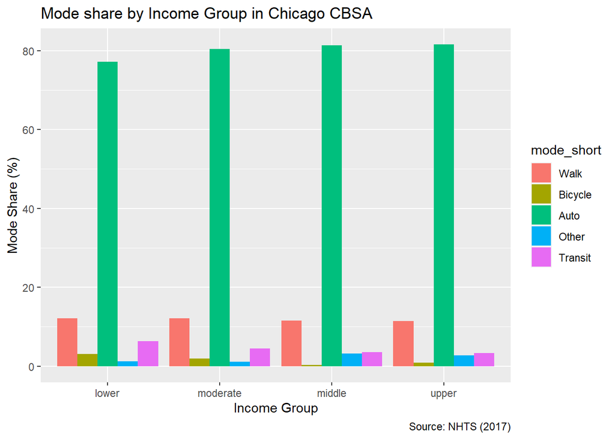

```r
# Your code comes here
ggplot(mode_by_income, aes(hhincome_short, per)) +
  geom_col(aes(fill = mode_short), position = "dodge", stat = 'identity') +
  labs(x = "Income Group", y = "Mode Share (%)", title = "Mode share by Income Group in Chicago CBSA",
       caption = "Source: NHTS (2017)", fill= "mode_short")
```

2) facet_wrap

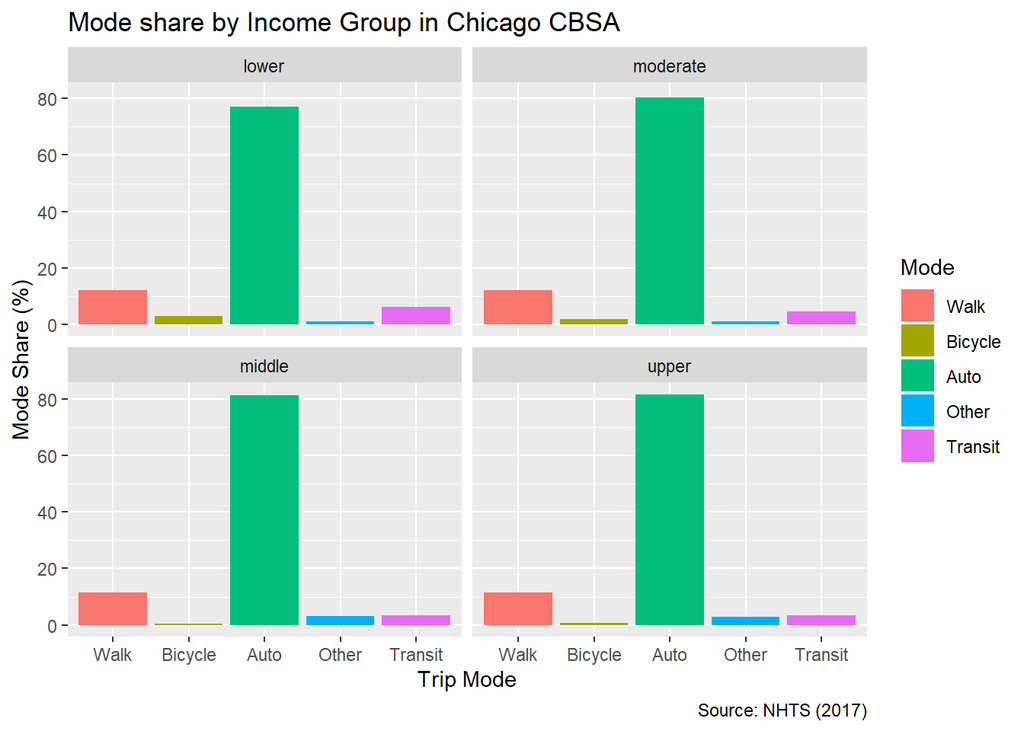

```r
ggplot(mode_by_income, aes(mode_short, per)) +
  geom_bar(aes(fill = mode_short), stat = 'identity') +
  facet_wrap( ~hhincome_short) +
  labs(x = "Trip Mode", y = "Mode Share (%)", title = "Mode share by Income Group in Chicago CBSA",
       caption = "Source: NHTS (2017)", fill= "mode_short") +
  guides(fill=guide_legend(title="Mode"))
```

# Using Household Data

**Task 2** Car ownership by income group(“HHVEHCNT” in household file)

```r
library(haven)
hh <- read_sav("C:/Lab0/2021_UP431/Lab1/Data/spss (2)/hhpub.sav")
```

```r
hh <- as_factor(hh)
names(hh)
```

```
##  [1] "houseid"    "travday"    "sampstrat"  "homeown"    "hhsize"
##  [6] "hhvehcnt"   "hhfaminc"   "pc"         "sphone"     "tab"
## [11] "walk"       "bike"       "car"        "taxi"       "bus"
## [16] "train"      "para"       "price"      "place"      "walk2save"
## [21] "bike2save"  "ptrans"     "hhrelatd"   "drvrcnt"    "cnttdhh"
## [26] "hhstate"    "hhstfips"   "numadlt"    "youngchild" "wrkcount"
## [31] "tdaydate"   "hhresp"     "lif_cyc"    "msacat"     "msasize"
## [36] "rail"       "urban"      "urbansize"  "urbrur"     "scresp"
## [41] "census_d"   "census_r"   "cdivmsar"   "hh_race"    "hh_hisp"
## [46] "hh_cbsa"    "resp_cnt"   "webuse17"   "smplsrce"   "wthhfin"
## [51] "hbhur"      "hthtnrnt"   "htppopdn"   "htresdn"    "hteempdn"
## [56] "hbhtnrnt"   "hbppopdn"   "hbresdn"
```

```r
levels(hh$hhfaminc)
```

```
##  [1] "I prefer not to answer" "I don't know"           "Not ascertained"
##  [4] "Less than $10,000"      "$10,000 to $14,999"     "$15,000 to $24,999"
##  [7] "$25,000 to $34,999"     "$35,000 to $49,999"     "$50,000 to $74,999"
## [10] "$75,000 to $99,999"     "$100,000 to $124,999"   "$125,000 to $149,999"
## [13] "$150,000 to $199,999"   "$200,000 or more"
```

```r
class(hh$hhvehcnt[1])# 지난주에 as_factor 잘못설명함 value들을 factorize하지는 않는듯..
```

```
## [1] "numeric"
```

```r
carOwnership_income <- hh %>%
  mutate(hhincome_short = fct_collapse(hhfaminc,
                                      "lower" = c("Less than $10,000","$10,000 to $14,999","$15,000 to $24,999","$25,000 to $34,999"),
                                       "moderate" = c("$35,000 to $49,999"),
                                       "middle" = c("$50,000 to $74,999"),
                                       "upper" = c("$75,000 to $99,999","$100,000 to $124,999","$125,000 to $149,999","$150,000 to $199,999","$200,000 or more"),
                                   Missing = c("I prefer not to answer","I don't know","Not ascertained"))) %>% filter(hhincome_short != "Missing")
```

1. % of hh with no vehicle

```r
# Your code comes here
noVehicle_income <- carOwnership_income %>% count(hhincome_short, hhvehcnt) %>%
  group_by(hhincome_short) %>%
  mutate(per = prop.table(n)*100) %>%
  filter(hhvehcnt == 0)

noVehicle_income
```

| hhincome_short | hhvehcnt | n | per |
| --- | --- | --- | --- |
| lower | 0 | 4843 | 13.2863296 |
| moderate | 0 | 320 | 2.0512821 |
| middle | 0 | 313 | 1.3979455 |
| upper | 0 | 439 | 0.8628314 |

2. mean of vehicles

```r
meanVehicle_income <- carOwnership_income %>% select(hhincome_short, hhvehcnt) %>%
  group_by(hhincome_short) %>%
  summarise(meanVehicle = mean(hhvehcnt))
meanVehicle_income
```

| hhincome_short | meanVehicle |
| --- | --- |
| lower | 1.364901 |
| moderate | 1.836346 |
| middle | 2.060786 |
| upper | 2.426659 |

```r
#carOwnership_income$wrkcount
```

3. mean vehicle to employee ratio (HHVEHCNT/WRKCOUNT)

```r
meanVehicle2employee_income <- carOwnership_income %>% select(hhincome_short, hhvehcnt, wrkcount) %>%
  group_by(hhincome_short) %>%
  summarise(ratio = mean(hhvehcnt/wrkcount, na.rm=TRUE)) # This arouses Inf! Guess why.
meanVehicle2employee_income
```

| hhincome_short | ratio |
| --- | --- |
| lower | Inf |
| moderate | Inf |
| middle | Inf |
| upper | Inf |

retired household? student?

```r
meanVehicle2employee_income <- carOwnership_income %>% select(hhincome_short, hhvehcnt, wrkcount) %>%
  mutate(ratio = ifelse(wrkcount!=0, hhvehcnt/wrkcount, hhvehcnt)) %>% # assumed that households with no worker has 1 worker.
    group_by(hhincome_short) %>%
  summarise(meanRatio = mean(ratio))
meanVehicle2employee_income
```

| hhincome_short | meanRatio |
| --- | --- |
| lower | 1.243964 |
| moderate | 1.584101 |
| middle | 1.679472 |
| upper | 1.724518 |

4. bar graph

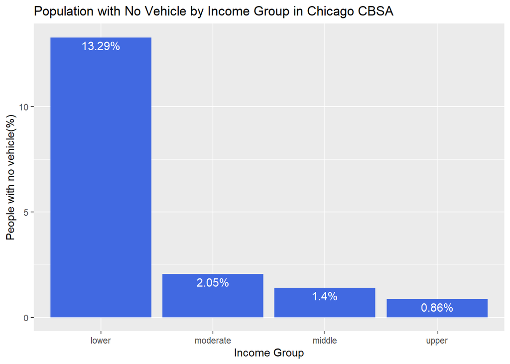

```r
noVehicle_income$per <- round(noVehicle_income$per,2)

ggplot(noVehicle_income, aes(hhincome_short, per))+
  geom_bar(stat="identity", fill = "royalblue")+
  labs(x="Income Group", y="People with no vehicle(%)", title="Population with No Vehicle by Income Group in Chicago CBSA")+
  geom_text(aes( label = paste0( per, "%" ), y = per ), vjust = 1.4, size = 4, color = "white")
```

#Using Vehicle Data

```r
# Your code comes here
veh <- read_sav("C:/Lab0/2021_UP431/Lab1/Data/spss (2)/vehpub.sav")
```

```r
veh <- as_factor(veh)
names(veh)
```

```
##  [1] "HOUSEID"   "VEHID"     "VEHYEAR"   "VEHAGE"    "MAKE"      "MODEL"
##  [7] "FUELTYPE"  "VEHTYPE"   "WHOMAIN"   "OD_READ"   "HFUEL"     "VEHOWNED"
## [13] "VEHOWNMO"  "ANNMILES"  "HYBRID"    "PERSONID"  "TRAVDAY"   "HOMEOWN"
## [19] "HHSIZE"    "HHVEHCNT"  "HHFAMINC"  "DRVRCNT"   "HHSTATE"   "HHSTFIPS"
## [25] "NUMADLT"   "WRKCOUNT"  "TDAYDATE"  "LIF_CYC"   "MSACAT"    "MSASIZE"
## [31] "RAIL"      "URBAN"     "URBANSIZE" "URBRUR"    "CENSUS_D"  "CENSUS_R"
## [37] "CDIVMSAR"  "HH_RACE"   "HH_HISP"   "HH_CBSA"   "SMPLSRCE"  "WTHHFIN"
## [43] "BESTMILE"  "BEST_FLG"  "BEST_EDT"  "BEST_OUT"  "HBHUR"     "HTHTNRNT"
## [49] "HTPPOPDN"  "HTRESDN"   "HTEEMPDN"  "HBHTNRNT"  "HBPPOPDN"  "HBRESDN"
## [55] "GSYRGAL"   "GSTOTCST"  "FEGEMPG"   "FEGEMPGA"  "GSCOST"    "FEGEMPGF"
```

**Task 3** Aggregate a vehicle level variable to HH level  
- Aggregate BESTMILE in vehicle file to the household level –> HHVMT, annual household VMT

```r
#veh$BESTMILE
```

```r
HOUSEID_list <- list(veh[["HOUSEID"]])
HOUSEID_list <- na.omit(HOUSEID_list)

veh_hh <- aggregate(as.numeric(veh$BESTMILE), by=HOUSEID_list, sum)
head(veh_hh)
```

|  | Group.1 | x |
| --- | --- | --- |
| 1 | 30000007 | 521003 |
| 2 | 30000008 | 457840 |
| 3 | 30000012 | 103993 |
| 4 | 30000019 | 260543 |
| 5 | 30000029 | 180076 |
| 6 | 30000039 | 242477 |

- Mean annual household VMT by four income group (INCGROUP) made in task 1

```r
veh <- left_join(veh_hh %>% group_by(Group.1) %>% mutate(id = row_number()), veh %>% group_by(HOUSEID) %>% mutate(id = row_number()), by = c("Group.1"="HOUSEID", "id"))

HHVMT_income <- veh %>%
  mutate(
    hhincome_short = fct_collapse(
      HHFAMINC,
      "lower" = c(
        "Less than $10,000",
        "$10,000 to $14,999",
        "$15,000 to $24,999",
        "$25,000 to $34,999"
      ),
      "moderate" = c("$35,000 to $49,999"),
      "middle" = c("$50,000 to $74,999"),
      "upper" = c(
        "$75,000 to $99,999",
        "$100,000 to $124,999",
        "$125,000 to $149,999",
        "$150,000 to $199,999",
        "$200,000 or more"
      ),
      Missing = c("I prefer not to answer", "I don't know", "Not ascertained")
    )
  )
```

```r
meanHHVMT_income <- HHVMT_income %>% filter(hhincome_short != "Missing") %>% select(hhincome_short, x) %>%
  group_by(hhincome_short) %>% summarise(HHVMT = mean(x))
meanHHVMT_income
```

| hhincome_short | HHVMT |
| --- | --- |
| lower | 158996.0 |
| moderate | 203336.7 |
| middle | 236671.9 |
| upper | 298664.0 |

- Attach ANOVA test

```r
library(car)
#car::recode

leveneTest(HHVMT_income$x, HHVMT_income$hhincome_short)
```

|  | Df | F value | Pr(>F) |
| --- | --- | --- | --- |
| group | 4 | 494.9198 | 0 |
|  | 123442 | NA | NA |

```r
oneway.test(HHVMT_income$x~HHVMT_income$hhincome_short, var.equal=F)
```

```
##
##  One-way analysis of means (not assuming equal variances)
##
## data:  HHVMT_income$x and HHVMT_income$hhincome_short
## F = 5175.3, num df = 4, denom df = 23730, p-value < 2.2e-16
```

**Task 4** A linear regression analysis at the household level - HHVMT = f(HHSIZE, HHVEHCNT/WRKCOUNT, INCGROUP  dummy, HBHUR  dummy)

1. create dummy variables (https://www.marsja.se/create-dummy-variables-in-r/)

```r
#install.packages("fastDummies")
library(fastDummies)
HHVMT_income <- HHVMT_income %>%
  mutate(HBHUR_new = fct_collapse(HBHUR,
                                      "SmallTown" = c("Small Town"),
                                       "SecondCity" = c("Second City"),
                                   Missing = c("Not ascertained"))) %>% filter(HBHUR_new != "Missing")

levels(HHVMT_income$HBHUR_new)
```

```
## [1] "Missing"    "SecondCity" "Rural"      "Suburban"   "SmallTown"
## [6] "Urban"
```

```r
HHVMT_income <- dummy_cols(HHVMT_income, select_columns = c("hhincome_short","HBHUR_new"))
```

2. regression

```r
# x: hh level vmt
HH_model <- lm(x ~ HHSIZE + HHVEHCNT/WRKCOUNT + hhincome_short_lower + hhincome_short_moderate + hhincome_short_middle + hhincome_short_upper + HBHUR_new_Urban + HBHUR_new_SmallTown + HBHUR_new_Suburban + HBHUR_new_Rural + HBHUR_new_SecondCity, data = HHVMT_income )
summary(HH_model)
```

```
##
## Call:
## lm(formula = x ~ HHSIZE + HHVEHCNT/WRKCOUNT + hhincome_short_lower +
##     hhincome_short_moderate + hhincome_short_middle + hhincome_short_upper +
##     HBHUR_new_Urban + HBHUR_new_SmallTown + HBHUR_new_Suburban +
##     HBHUR_new_Rural + HBHUR_new_SecondCity, data = HHVMT_income)
##
## Residuals:
##     Min      1Q  Median      3Q     Max
## -992005  -69162   -2021   66266 1494989
##
## Coefficients: (1 not defined because of singularities)
##                         Estimate Std. Error t value Pr(>|t|)
## (Intercept)              23777.2     1863.8  12.757  < 2e-16 ***
## HHSIZE                   19284.8      291.3  66.212  < 2e-16 ***
## HHVEHCNT                 55912.5      369.8 151.201  < 2e-16 ***
## hhincome_short_lower    -11203.9     1716.0  -6.529 6.64e-11 ***
## hhincome_short_moderate   5479.2     1812.0   3.024  0.00250 **
## hhincome_short_middle    16429.9     1753.2   9.371  < 2e-16 ***
## hhincome_short_upper     37094.0     1687.0  21.988  < 2e-16 ***
## HBHUR_new_Urban         -12505.9     1093.7 -11.434  < 2e-16 ***
## HBHUR_new_SmallTown      14156.0      898.8  15.750  < 2e-16 ***
## HBHUR_new_Suburban        2394.0      902.0   2.654  0.00795 **
## HBHUR_new_Rural          27401.6      904.6  30.290  < 2e-16 ***
## HBHUR_new_SecondCity          NA         NA      NA       NA
## HHVEHCNT:WRKCOUNT        12273.1      135.8  90.347  < 2e-16 ***
## ---
## Signif. codes:  0 '***' 0.001 '**' 0.01 '*' 0.05 '.' 0.1 ' ' 1
##
## Residual standard error: 102300 on 123331 degrees of freedom
## Multiple R-squared:  0.5655, Adjusted R-squared:  0.5654
## F-statistic: 1.459e+04 on 11 and 123331 DF,  p-value: < 2.2e-16
```

- Discuss what additional variables do you want to include?

```r
# Your code comes here
```